# Лабораторная работа №3

Дисциплина: Операционные системы

Савостин Олег

Российский университет дружбы народов, Москва, Россия

# Информация

## Докладчик

- Савостин Олег
- студент Физики-математического факультета, Математика и Механика.
- Российский университет дружбы народов
- 1032245472@pfur..ru

# Цель работы

Целью работы является ознакомление с файловой системой Linux, её структурой, именами и содержанием каталогов. Приобретение практических навыков по применению команд для работы с файлами и каталогами, по управлению процессами (и работами), по проверке использования диска и обслуживанию файловой системы.

# Задание

1. Использование команд.

# Теоретическое введение

Для создания текстового файла можно использовать команду touch. Формат команды: 1 touch имя-файла Для просмотра файлов небольшого размера можно использовать команду cat. Формат команды: 1 cat имя-файла Для просмотра файлов постранично удобнее использовать команду less. Формат команды: 1 less имя-файла Следующие клавиши используются для управления процессом просмотра: – Space — переход к следующей странице, – ENTER — сдвиг вперёд на одну строку, – b — возврат на предыдущую страницу, – h — обращение за подсказкой, – q — выход из режима просмотра файла.

# Теоретическое введение

# Теоретическое введение

Команда cp используется для копирования файлов и каталогов. Формат команды: 1 cp [-опции] исходный_файл целевой_файл Примеры: 1. Копирование файла в текущем каталоге. Скопировать файл ~/abc1 в файл april и в файл may: 1 cd 2 touch abc1 3 cp abc1 april 4 cp abc1 may 2. Копирование нескольких файлов в каталог. Скопировать файлы april и may в каталог monthly: 1 mkdir monthly 2 cp april may monthly 3. Копирование файлов в произвольном каталоге. Скопировать файл monthly/may в файл с именем june: 1 cp monthly/may monthly/june 2 ls monthly

# Теоретическое введение

Опция i в команде cp выведет на экран запрос подтверждения о перезаписи файла. Для рекурсивного копирования каталогов, содержащих файлы, используется команда cp с опцией r. Примеры: 1. Копирование каталогов в текущем каталоге. Скопировать каталог monthly в каталог monthly.00: 1 mkdir monthly.00 2 cp -r monthly monthly.00 2. Копирование каталогов в произвольном каталоге. Скопировать каталог monthly.00 в каталог /tmp 1 cp -r monthly.00 /tmp

# Выполнение лабораторной работы

Выполняю все примеры в лабораторной работе.

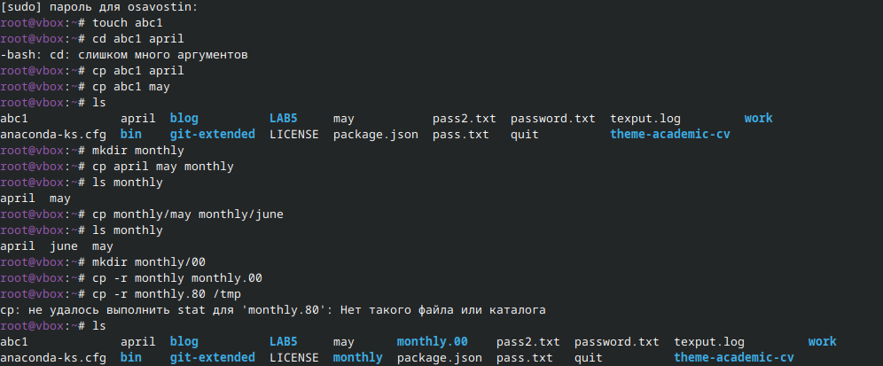

Копирование файлов

# Выполнение лабораторной работы

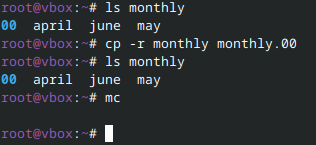

Копирование репозиториев в другие репозитории

# Выполнение лабораторной работы

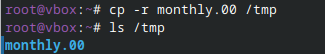

Копирование репозитория

# Выполнение лабораторной работы

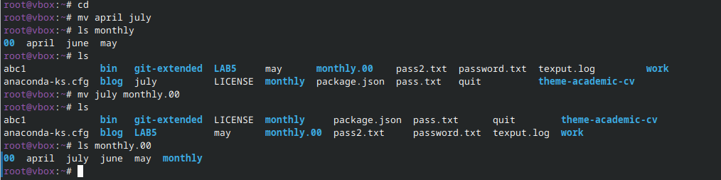

Перемещение файлов

# Выполнение лабораторной работы

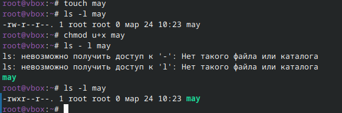

Создание файлов

# Выполнение лабораторной работы

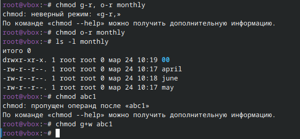

Изменение права доступа

# Выполнение лабораторной работы

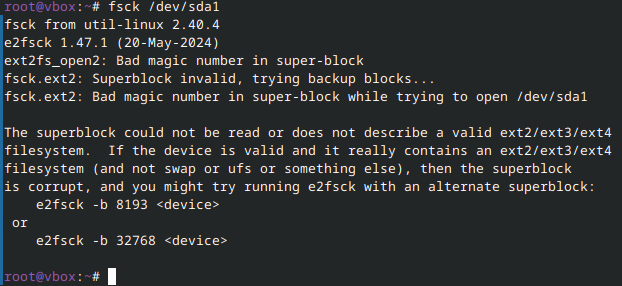

fsck

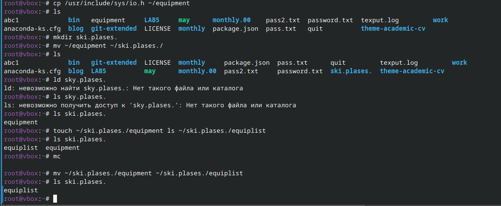

Создание нужных каталогов.

# Выполнение лабораторной работы

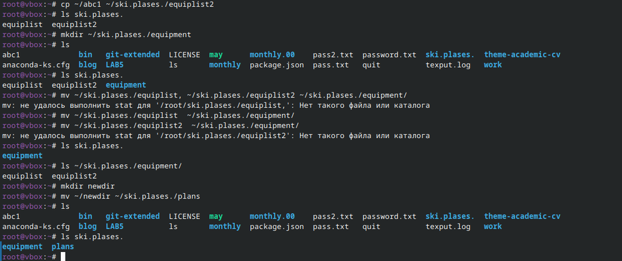

Выполнение команд

# Выполнение лабораторной работы

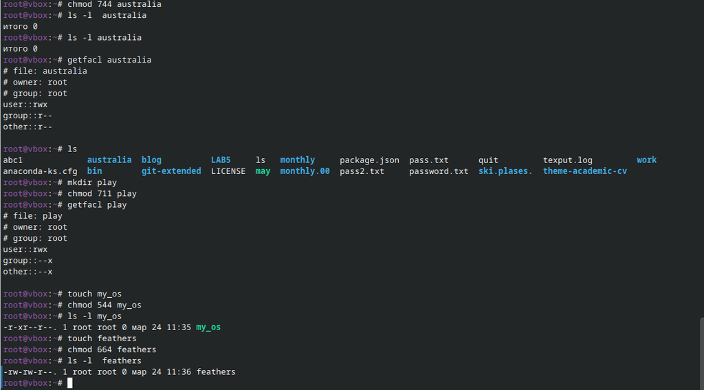

Права доступа

# Выполнение лабораторной работы

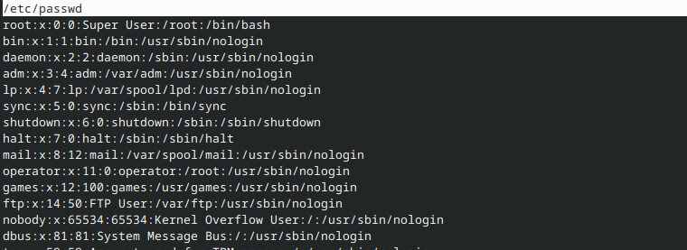

Содержимое файла

# Выполнение лабораторной работы

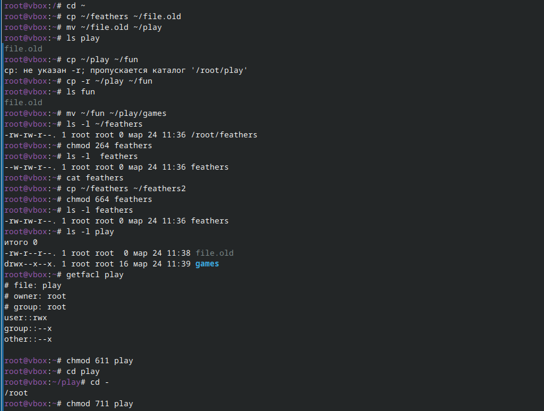

Завершение выполнение задач

# Выполнение лабораторной работы

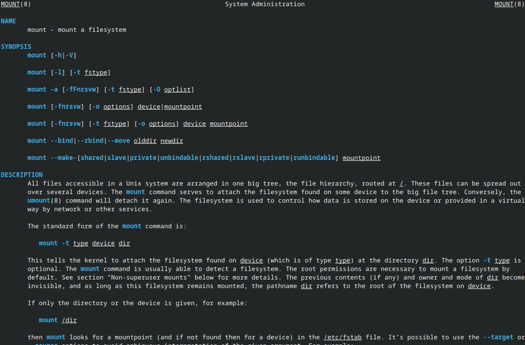

mount

# Выполнение лабораторной работы

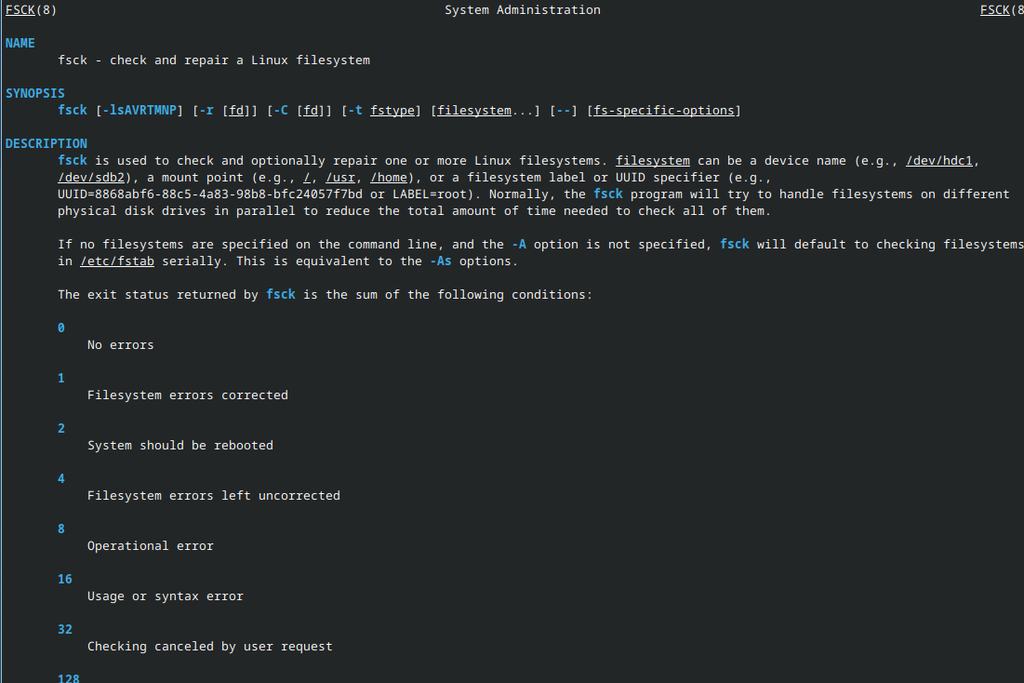

fsck

# Выполнение лабораторной работы

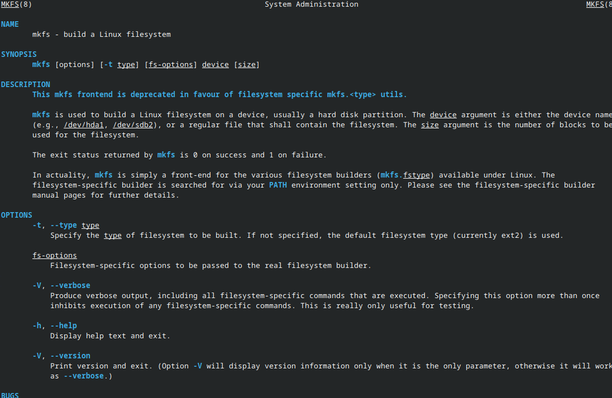

mkfs

# Выполнение лабораторной работы

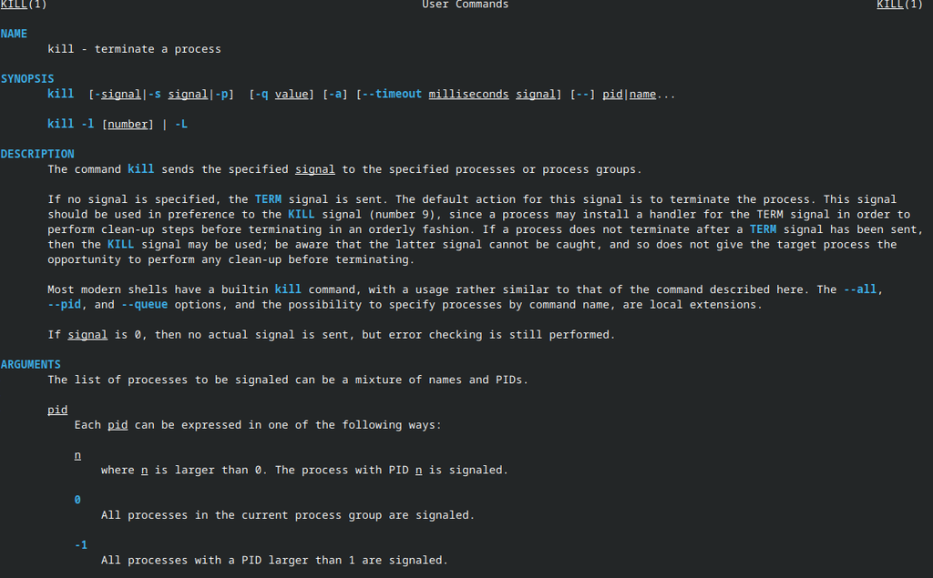

kill

# Выводы

В ходе данной лабораторной работы я освоил навыки пользования файловой системой Linux, её структурой, именами и содержанием каталогов

# Список литературы